# DEG Analysis SIG18

EYW

2026-08-06

```r
library(tidyverse)
```

```r
library(ggplot2)
library(patchwork)
library(DESeq2)
library(IHW)
library(RColorBrewer)
library(pheatmap)
knitr::opts_chunk$set(echo = TRUE)
```

```r
source("../../functions/r_custom/plotting_fxns.R")
theme_set(theme_Publication())
```

This Rmd ports the unified condition-level DEG + interaction-scoring workflow developed in SIG26 to the SIG18 dataset.

SIG18 differs from SIG26 in its reference state: `ligand1` is the Th-polarizing condition with baseline **Th0** (activated but unpolarized), while `ligand2` is TNF with baseline **none**. The fully-untreated reference is therefore `Th0_none`. We encode this by treating `Th0` as the baseline for `ligand1`, so the derived `condition` variable behaves exactly like SIG26’s: `Th0_none` -> `none`, a single polarizing ligand -> its own name (e.g. `Th1`), `Th0_TNF` -> `TNF`, and a polarized + TNF well -> the combination (e.g. `Th1-TNF`).

```r
# Reference (baseline) value of each ligand. A sample is "untreated" for a
# ligand when that ligand equals its baseline.
baseline1 <- "Th0"    # ligand1 (Th polarization) baseline
baseline2 <- "none"   # ligand2 (TNF) baseline
```

### Import Data

```r
counts <- read.csv("../../processing_outs/count_matrix_umiDeDup_SIG18.csv", row.names = "X")
colnames(counts) <- gsub("\\.", "-", colnames(counts))

metadata <- read_csv("../../processing_outs/processed_metadata_SIG18.csv")
featureNames <- read_csv("../../processing_outs/featureNames_SIG18.csv") %>%
  dplyr::select(-category)
```

Mouse 4 and mouse 9 are dropped: they were both on the very edge of the plate and clustered together anomalously across analyses.

```r
metadata <- metadata %>%
  filter(!replicate %in% c("mouse4", "mouse9")) %>%
  filter(sample_ID != "TGFb_none_mouse3_F_E06_col7_SIG18")
```

```r
# Derive a single `condition` factor from the two ligand columns:
#   - both ligands at baseline -> "none"  (Th0_none, the untreated reference)
#   - one ligand active        -> that ligand's name (single-ligand condition)
#   - both ligands active       -> "ligand1-ligand2" (combination)
make_condition <- function(l1, l2) {
  parts <- c(if (l1 != baseline1) l1, if (l2 != baseline2) l2)
  if (length(parts) == 0) "none" else paste(parts, collapse = "-")
}

metaDF <- metadata %>%
  mutate(
    condition = map2_chr(ligand1, ligand2, make_condition),
    replicate = factor(replicate),
    sex       = factor(sex),
    ligand1   = factor(ligand1, levels = c(baseline1, sort(setdiff(unique(ligand1), baseline1)))),
    ligand2   = factor(ligand2, levels = c(baseline2, sort(setdiff(unique(ligand2), baseline2)))),
    condition = factor(condition, levels = c("none", sort(setdiff(unique(condition), "none"))))
  ) %>%
  mutate(condition = factor(condition, c("none","TNF",
                                         "Th1","Th1-TNF",
                                         "Th2","Th2-TNF",
                                         "Th17","Th17-TNF",
                                         "iTreg","iTreg-TNF",
                                         "TGFb","TGFb-TNF"))) %>%
  as.data.frame()
rownames(metaDF) <- metaDF$sample_ID

counts <- counts[, rownames(metaDF)]
```

### Helper Functions

```r
# Build DDS object with counts filtering
build_dds <- function(counts_mat, meta, design, min_count = 10, min_samples = 3) {
  dds <- DESeqDataSetFromMatrix(counts_mat, colData = meta, design = design)
  dds <- dds[rowSums(counts(dds) >= min_count) >= min_samples, ]
  DESeq(dds, parallel = TRUE)
}

# Extract DEG results for a vector of coefficient names and combine into one tibble
extract_deg_results <- function(dds, terms, label_col = "term", clean_fn = identity) {
  map_dfr(terms, function(term) {
    results(dds, name = term,
            independentFiltering = FALSE, filterFun = ihw, parallel = TRUE) %>%
      as_tibble(rownames = "ensembl_ID") %>%
      left_join(featureNames, by = "ensembl_ID") %>%
      mutate(!!label_col := clean_fn(term)) %>%
      arrange(padj)
  })
}

# Look up the exact resultsNames() term for a condition value.
# Handles DESeq2 encoding hyphens as either "-" or "." in model matrix names.
cond_term <- function(res_names, cond) {
  pat  <- paste0("^condition_", gsub("-", "[-.]", cond, fixed = FALSE), "_vs_none$")
  hits <- res_names[grepl(pat, res_names)]
  if (length(hits) != 1) stop("Expected 1 match for '", cond, "', found: ", length(hits))
  hits
}
```

### QC Plots

```r
# Condition-level model on all samples; reused for both QC and all DEG analyses below
dds_cond <- build_dds(counts, metaDF, ~ condition + replicate)
vsd      <- vst(dds_cond, blind = TRUE)
```

#### Sample Distance Heatmap

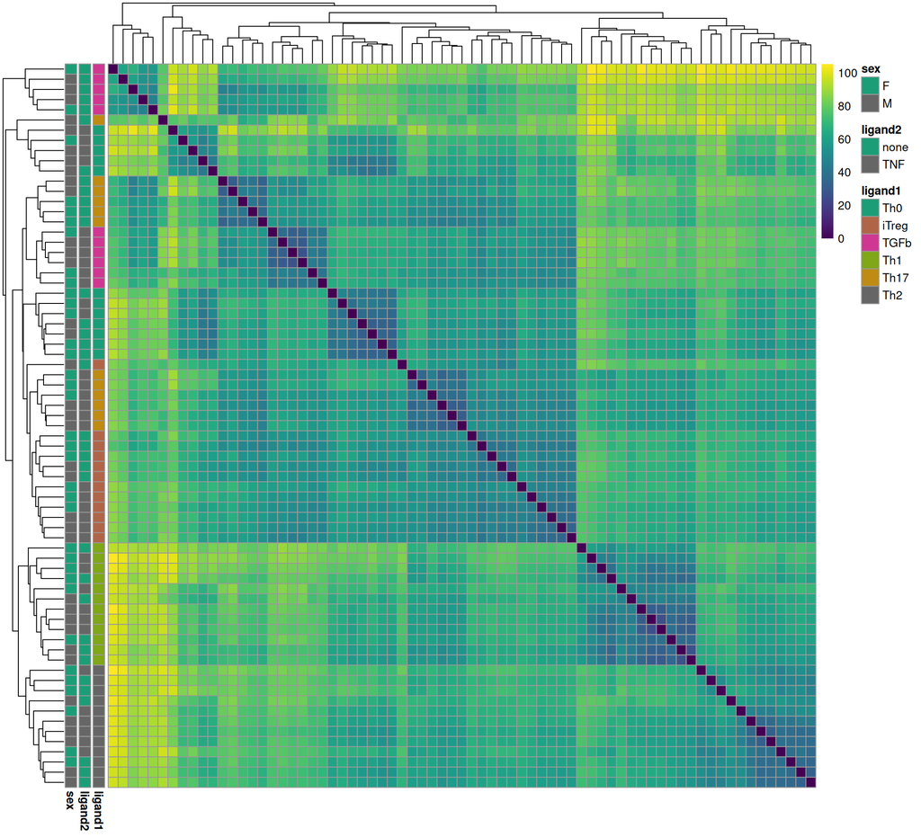

```r
sampleDists <- dist(t(assay(vsd)))
distMatrix  <- as.matrix(sampleDists)
rownames(distMatrix) <- colnames(dds_cond)
colnames(distMatrix) <- colnames(dds_cond)

ann_df <- as.data.frame(colData(vsd)[, c("ligand1", "ligand2", "sex")])
mk_pal <- function(n) colorRampPalette(brewer.pal(8, "Dark2"))(n)
ann_colors <- list(
  ligand1 = setNames(mk_pal(length(unique(ann_df$ligand1))), sort(unique(ann_df$ligand1))),
  ligand2 = setNames(mk_pal(length(unique(ann_df$ligand2))), sort(unique(ann_df$ligand2))),
  sex     = setNames(mk_pal(length(unique(ann_df$sex))),     sort(unique(ann_df$sex)))
)

pheatmap(distMatrix,
         clustering_distance_rows = sampleDists,
         clustering_distance_cols = sampleDists,
         col = viridisLite::viridis(100),
         annotation_row = ann_df,
         annotation_colors = ann_colors,
         show_rownames = FALSE,
         show_colnames = FALSE)
```

#### Per-Replicate Distance Heatmaps

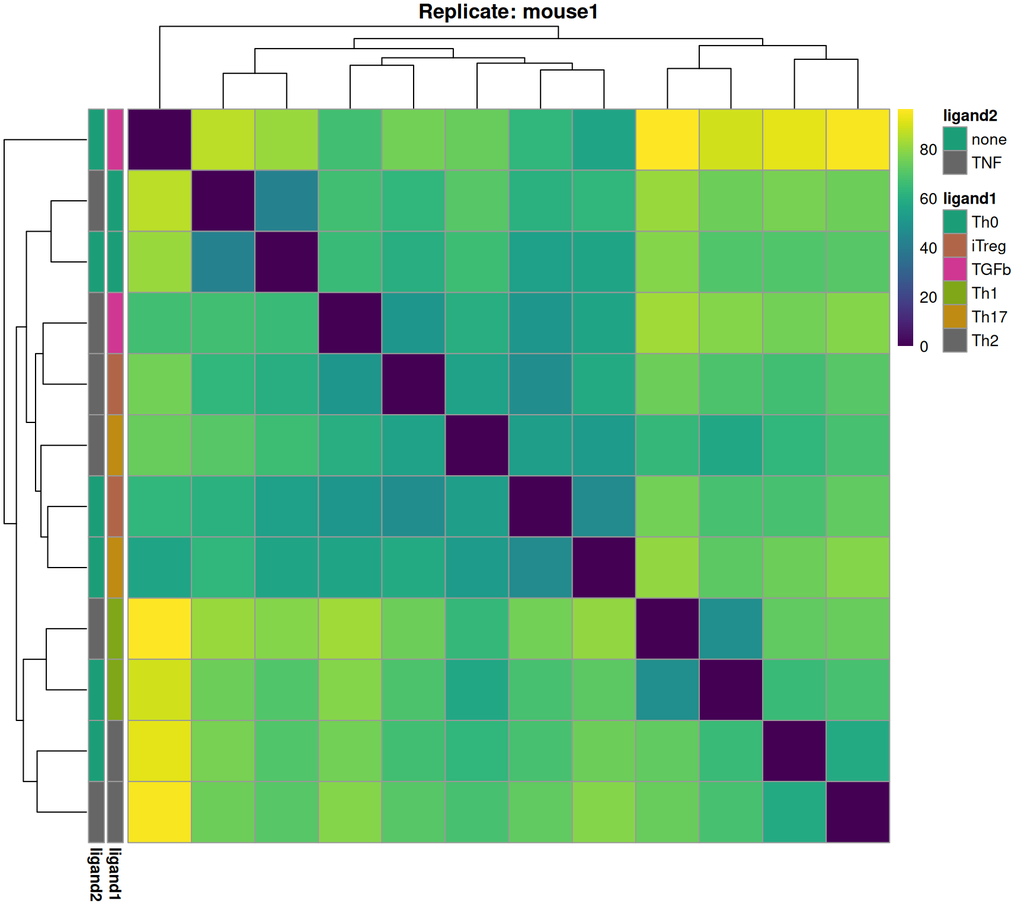

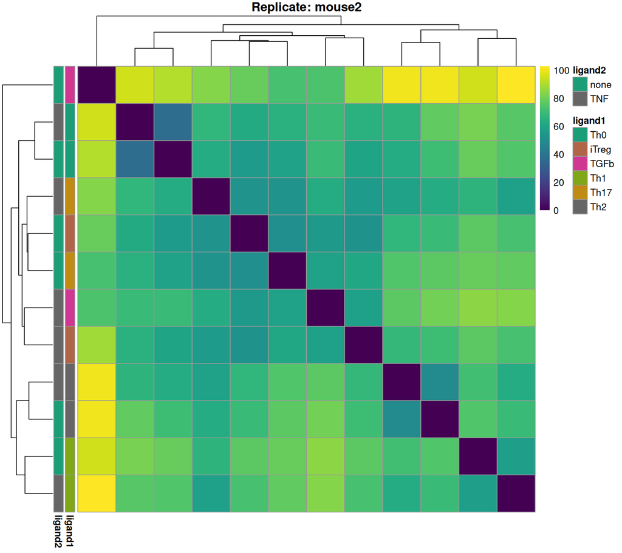

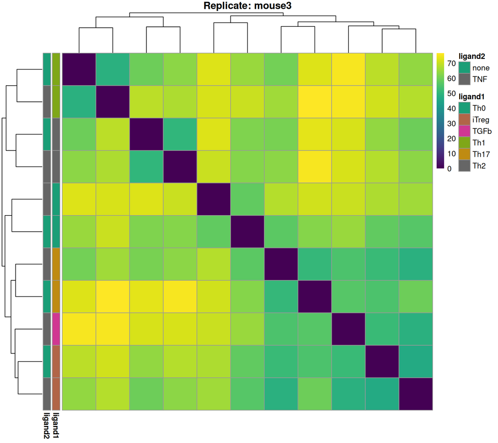

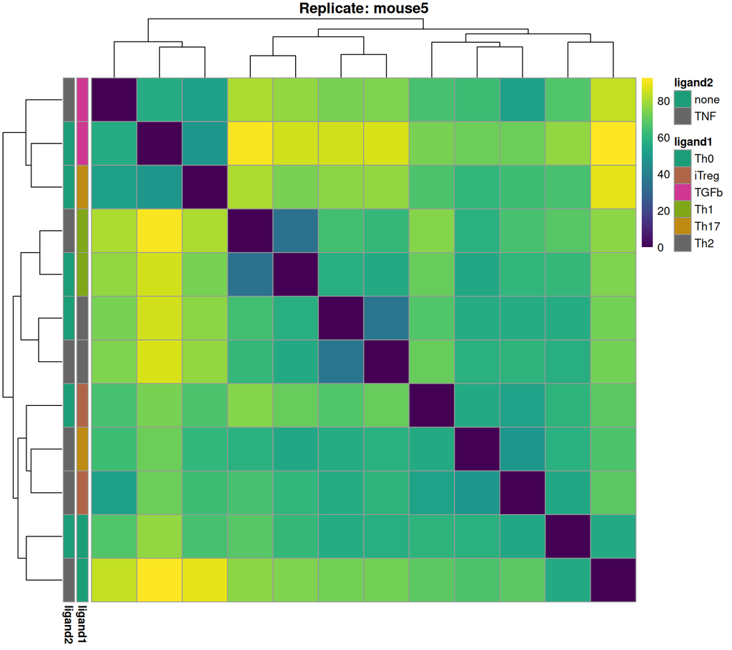

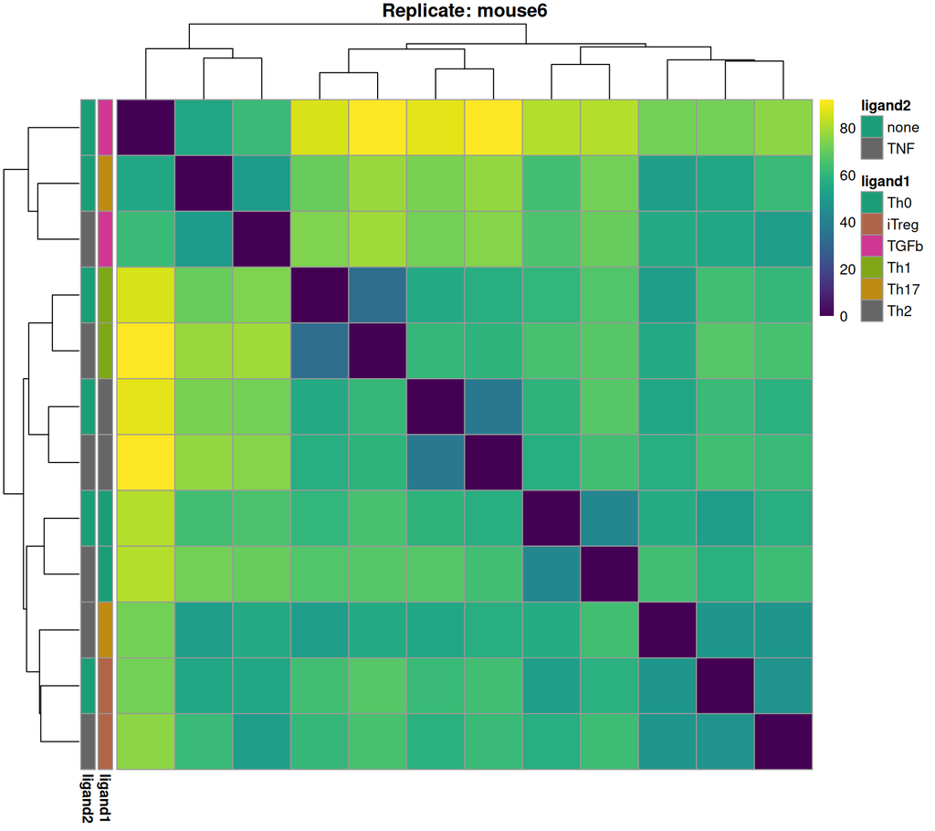

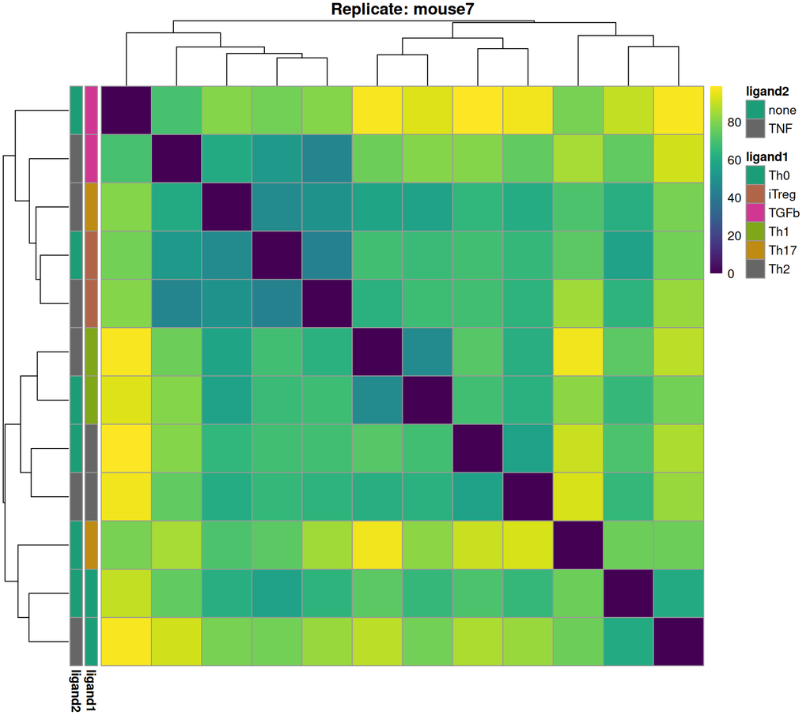

```r
for (rep in levels(metaDF$replicate)) {
  keep    <- colnames(vsd)[colData(vsd)$replicate == rep]
  vsd_rep <- vsd[, keep]

  dists_rep  <- dist(t(assay(vsd_rep)))
  mat_rep    <- as.matrix(dists_rep)
  rownames(mat_rep) <- colnames(vsd_rep)
  colnames(mat_rep) <- colnames(vsd_rep)

  ann_rep <- as.data.frame(colData(vsd_rep)[, c("ligand1", "ligand2")])
  ann_colors_rep <- list(
    ligand1 = setNames(mk_pal(length(unique(ann_rep$ligand1))), sort(unique(ann_rep$ligand1))),
    ligand2 = setNames(mk_pal(length(unique(ann_rep$ligand2))), sort(unique(ann_rep$ligand2)))
  )

  pheatmap(mat_rep,
           clustering_distance_rows = dists_rep,
           clustering_distance_cols = dists_rep,
           col = viridisLite::viridis(100),
           annotation_row = ann_rep,
           annotation_colors = ann_colors_rep,
           show_rownames = FALSE,
           show_colnames = FALSE,
           main = paste("Replicate:", rep))
}
```

#### PCA

```r
p1 <- plotPCA(vsd, intgroup = "ligand1",   ntop = 2000) + theme(aspect.ratio = 1)
```

```
## using ntop=2000 top features by variance
```

```r
p2 <- plotPCA(vsd, intgroup = "ligand2",   ntop = 2000) + theme(aspect.ratio = 1)
```

```
## using ntop=2000 top features by variance
```

```r
p3 <- plotPCA(vsd, intgroup = "condition",   ntop = 2000) + theme(aspect.ratio = 1) +
  scale_color_brewer(palette = "Paired")
```

```
## using ntop=2000 top features by variance
```

```r
p4 <- plotPCA(vsd, intgroup = "replicate", ntop = 2000) + theme(aspect.ratio = 1)
```

```
## using ntop=2000 top features by variance
```

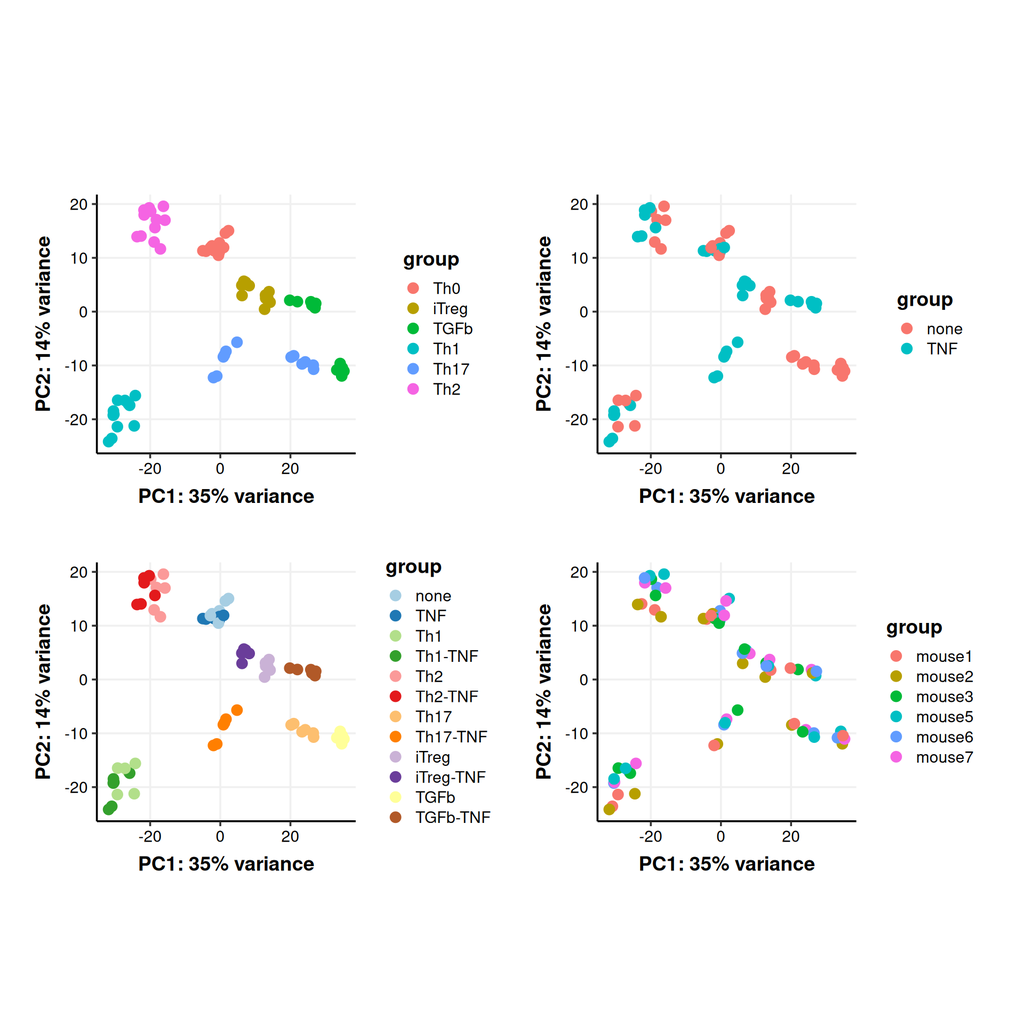

```r
p1 + p2 + p3 + p4 + plot_layout(ncol = 2)
```

```r
ggsave("../../analysis_outs/plots/SIG18_PCA.pdf")
```

### Analysis 1: Condition Effects

Effect of every condition vs. none (Th0_none), using the condition-level model. Captures both single-ligand and combination conditions in a single unified analysis.

```r
cond_terms <- grep("^condition_", resultsNames(dds_cond), value = TRUE)

res_conditions <- extract_deg_results(
  dds_cond, cond_terms,
  label_col = "condition",
  # DESeq2 may encode hyphens as dots in term names; restore hyphens for readability
  clean_fn  = function(x) gsub("\\.", "-", gsub("^condition_|_vs_none$", "", x))
)
```

```r
write_csv(res_conditions, "../../analysis_outs/deg_updated/res_conditions_SIG18.csv")
```

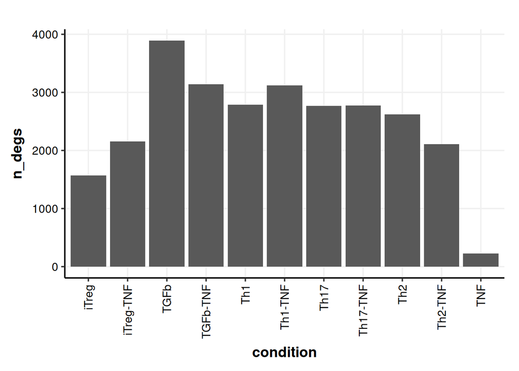

```r
res_conditions %>%
  filter(padj < 0.01) %>%
  group_by(condition) %>%
  summarise(n_degs = n()) %>%
  ggplot(aes(x = condition, y = n_degs)) +
    geom_col() +
    theme(axis.text.x = element_text(angle = 90, vjust = 0.5, hjust = 1))
```

### Analysis 2: Interaction Scoring

For each gene in each combination condition, quantifies whether the combined response is greater than (synergy), less than (buffering), or equal to (additive) the sum of the individual responses.

All LFC values are pulled directly from DESeq2 model.

- `lfc_lig1`: logFC of ligand1 alone vs. none (Th polarization vs. Th0)
- `lfc_lig2`: logFC of ligand2 alone vs. none (TNF vs. none, on Th0 background)
- `lfc_interaction`: `lfc_combo − lfc_lig1 − lfc_lig2` (deviation from additivity)
- `lfc_total`: `lfc_lig1 + lfc_lig2 + lfc_interaction` = `lfc_combo`
- `interaction_score`: `lfc_interaction / lfc_total` — fraction of total effect attributable to non-additivity (set to 0 when `padj_interaction > 0.1`)
- `padj_interaction`: adjusted p-value from the synergy contrast `lfc_combo − lfc_lig1 − lfc_lig2`

**Classification**: - `synergy positive`: interaction significant, total effect positive, score > 0 - `synergy negative`: interaction significant, total effect negative, score > 0 - `buffering`: interaction significant, score < 0 - `none`: interaction not significant

Note: ligand1/ligand2 assignment is arbitrary; scores and classes are symmetric with respect to swapping the two ligands.

```r
# Define combo conditions and respective ligands (both ligands active,
# i.e. a polarized Th condition combined with TNF)
combo_map <- metaDF %>%
  filter(as.character(ligand1) != baseline1, as.character(ligand2) != baseline2) %>%
  dplyr::select(condition, ligand1, ligand2) %>%
  mutate(across(everything(), as.character)) %>%
  distinct()

combo_map
```

|  | condition | ligand1 | ligand2 |
| --- | --- | --- | --- |
| Th17_TNF_mouse7_M_F10_col8_SIG18 | Th17-TNF | Th17 | TNF |
| Th1_TNF_mouse1_F_B02_col4_SIG18 | Th1-TNF | Th1 | TNF |
| TGFb_TNF_mouse3_F_F06_col8_SIG18 | TGFb-TNF | TGFb | TNF |
| Th2_TNF_mouse1_F_B03_col4_SIG18 | Th2-TNF | Th2 | TNF |
| iTreg_TNF_mouse5_M_B11_col4_SIG18 | iTreg-TNF | iTreg | TNF |

#### Synergy contrast p-values

Here we are calculating interaction effects using a contrast design. e.g. Th1-TNF_vs_none - (Th1_vs_none + TNF_vs_none)

```r
rn_cond <- resultsNames(dds_cond)

res_synergy_pvals <- map_dfr(seq_len(nrow(combo_map)), function(i) {
  row <- combo_map[i, ]
  results(dds_cond,
          contrast = list(
            c(cond_term(rn_cond, row$condition)),
            c(cond_term(rn_cond, row$ligand1), cond_term(rn_cond, row$ligand2))
          ),
          independentFiltering = FALSE, filterFun = ihw, parallel = TRUE) %>%
    as_tibble(rownames = "ensembl_ID") %>%
    dplyr::select(ensembl_ID, lfc_interaction = log2FoldChange, padj_interaction = padj) %>%
    mutate(condition = row$condition)
})
```

#### Compute interaction scores

```r
lfc_lookup <- res_conditions %>%
  dplyr::select(ensembl_ID, gene, condition, log2FoldChange) %>%
  dplyr::rename(lfc = log2FoldChange)

interaction_raw <- map_dfr(seq_len(nrow(combo_map)), function(i) {
  row <- combo_map[i, ]
  lfc_lookup %>%
    filter(condition == row$condition) %>%
    dplyr::select(ensembl_ID, gene, lfc_combo = lfc) %>%
    left_join(
      lfc_lookup %>% filter(condition == row$ligand1) %>%
        dplyr::select(ensembl_ID, lfc_lig1 = lfc),
      by = "ensembl_ID"
    ) %>%
    left_join(
      lfc_lookup %>% filter(condition == row$ligand2) %>%
        dplyr::select(ensembl_ID, lfc_lig2 = lfc),
      by = "ensembl_ID"
    ) %>%
    left_join(
      res_synergy_pvals %>% filter(condition == row$condition) %>%
        dplyr::select(ensembl_ID, lfc_interaction, padj_interaction),
      by = "ensembl_ID"
    ) %>%
    mutate(condition = row$condition, ligand1 = row$ligand1, ligand2 = row$ligand2)
})
```

#### Classify interaction effects

```r
interaction_scored <- interaction_raw %>%
  mutate(
    lfc_total       = lfc_combo,
    interaction_score = case_when(
      is.na(padj_interaction) | padj_interaction > 0.1 ~ 0,
      TRUE ~ lfc_interaction / lfc_total
    ),
    interaction_class = case_when(
      padj_interaction <= 0.1 & lfc_total > 0 & interaction_score > 0 ~ "synergy positive",
      padj_interaction <= 0.1 & lfc_total < 0 & interaction_score > 0 ~ "synergy negative",
      padj_interaction <= 0.1 & interaction_score < 0                  ~ "buffering",
      TRUE ~ "none"
    )
  )
```

```r
interaction_scored %>%
  filter(interaction_class != "none") %>%
  group_by(condition, interaction_class) %>%
  summarise(n = n(), .groups = "drop") %>%
  arrange(condition, interaction_class)
```

| condition | interaction_class | n |
| --- | --- | --- |
| TGFb-TNF | buffering | 1592 |
| TGFb-TNF | synergy negative | 594 |
| TGFb-TNF | synergy positive | 626 |
| Th1-TNF | buffering | 38 |
| Th1-TNF | synergy negative | 31 |
| Th1-TNF | synergy positive | 44 |
| Th17-TNF | buffering | 602 |
| Th17-TNF | synergy negative | 551 |
| Th17-TNF | synergy positive | 618 |
| Th2-TNF | buffering | 93 |

[output cut: 5 more lines]

```r
write_csv(interaction_scored, "../../analysis_outs/deg_updated/res_interaction_scored_SIG18.csv")
```